# Week 1 Peer Review

Your objective is to replicate these figures, created using the Center of Legislative Effectiveness Data. These figures are similar to those we completed in the lecture videos.

### Put your name here: Marcio Woitek

**IMPORTANT: Filter your data so you are only displaying information for the 115th Congress.**

## Exercise 1

Hints:

- For the x-axis, use the variable `dwnom1`.
- For the y-axis, use the variable `all_pass`.
- Make sure you recode the data for the `female` variable and rename it as `Gender` to generate the correct labels for the legend.
- Set the color aesthetic in the `ggplot()` function to make the color of the dots change based on `Gender`.
- Make sure the axis labels are correct.

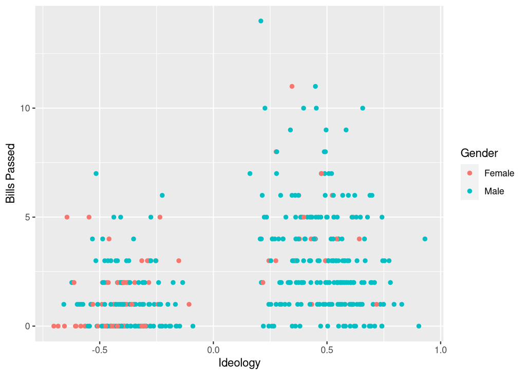

## Exercise 2

Hints:

- For the x-axis, use the variable `votepct`.
- For the y-axis, use `all_pass`.
- Make sure you recode the data for the `female` variable to generate the correct labels for the legend. Rename that column `Gender` (you may have already done this in the last exercise).
- Make sure you recode the data for `majority` variable to generate the correct labels of the faceted figures.
- Set the color aesthetic in the `ggplot()` function to make the color of the dots change based on `Gender`.
- Use `scale_color_manual()` to set the colors to green for males and orange for females.
- Make sure the axis labels are correct.

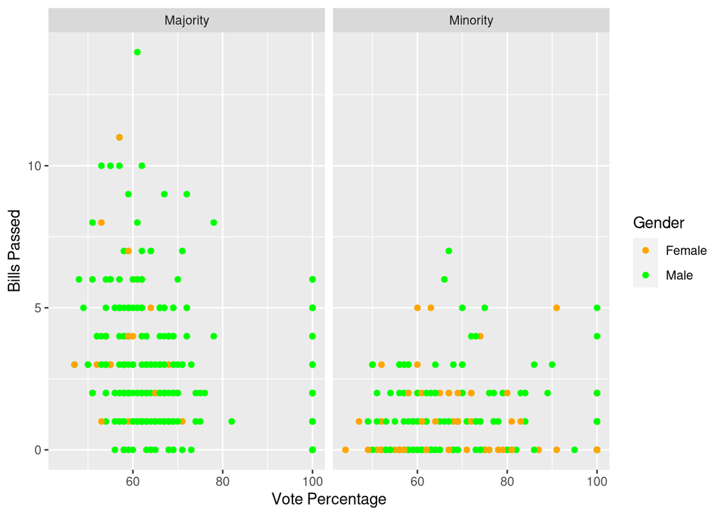

## Exercise 3

Hints:

- For the y-axis, use the variable `les`.
- Make sure you recode the data for the `majority` variable to generate the correct labels (you may have already done this in the last exercise).
- Make sure the axis labels and figure title are correct.

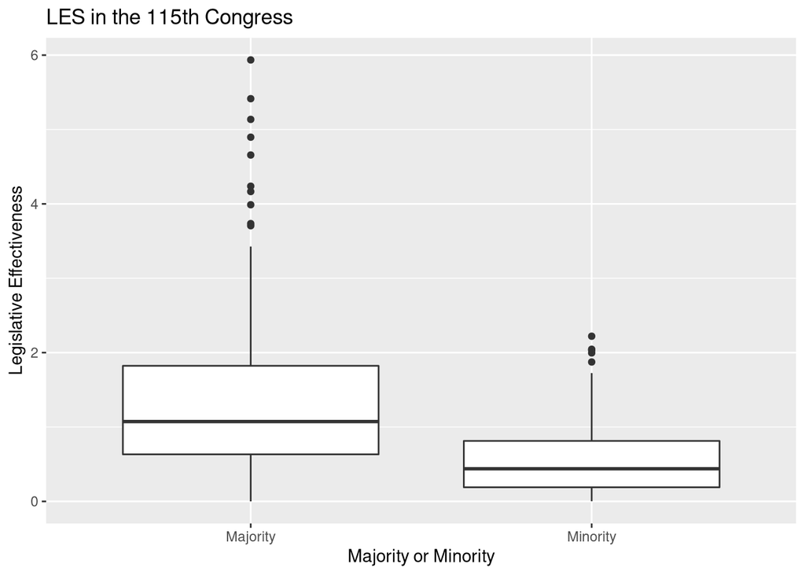